# Simple Linear Regression

```r
# Load your libraries
library(car)
library(tidyverse)
library(pander)

ramones_raw <- read.csv("../Data/ramones.csv")

ramones <- ramones_raw %>% mutate(song_length_minutes = song_length_minute + (song_length_second) * (1/60))

# Load your data after saving a csv file in your Data folder.
# You can use either
#   someName <- read.csv("../Data/YourDataFileName.csv", header=TRUE)
# or
#   library(readr)
#   someName <- read_csv("../Data/YourDataFileName.csv")

# Don't forget to run "Session -> Set Working Directory -> To Source file location"
```

## Background

The Ramones were an American punk rock band from 1974 to 1996 with 14 studio albums. They were severely underrated during their time, and it was until after their disbandment that they started to become recognized for their impact on rock music.

While the Ramones didn’t get much airplay, and didn’t show up on the charts very often, today we have many different mediums to help us gain a better understanding of the attributes and trends of the music we listen to.

I would like to see if valence has a meaningful relationship to popularity, in other words, **do happier ramones songs tend to be more popular (or less popular)?**

## Method

I used the [Spotify API](https://developer.spotify.com/documentation/web-api/reference/tracks/get-track/) to gather audio analytics about every Ramones song on each of their 14 studio albums.

I will be using regression analysis to study the correlation between these attributes. As part of the analysis, I wish to discover for every point of valence, how many more points of popularity increase or decrease we can expect to see on average.

## Hypothesis

In order to test our hypothesis, we will use a linear regression model:

$$\underbrace{Y_i}_\text{Popularity} = \beta_0 + \beta_1 \underbrace{X_i}_\text{Valence} + \epsilon_i \quad \text{where} \ \epsilon_i \sim N(0, \sigma^2)$$
We will assume that there is no meaningful relationship, until proven otherwise. This will be our null hypothesis.

$$H_0: \beta_1 = 0$$
If we find compelling evidence to prove some kind of relationship we will reject the previous assumption. This will be our alternative hypothesis:

$$H_a: \beta_1 \neq 0$$
Significance will be determined at:

$$\alpha = 0.05$$

## Analysis

Our linear regression model is as follows:
$$\underbrace{\hat{Y}_i}_\text{Popularity} = 12.63 + .1363 \underbrace{X_i}_\text{Valence.}$$

Which can be represented by the following plot:

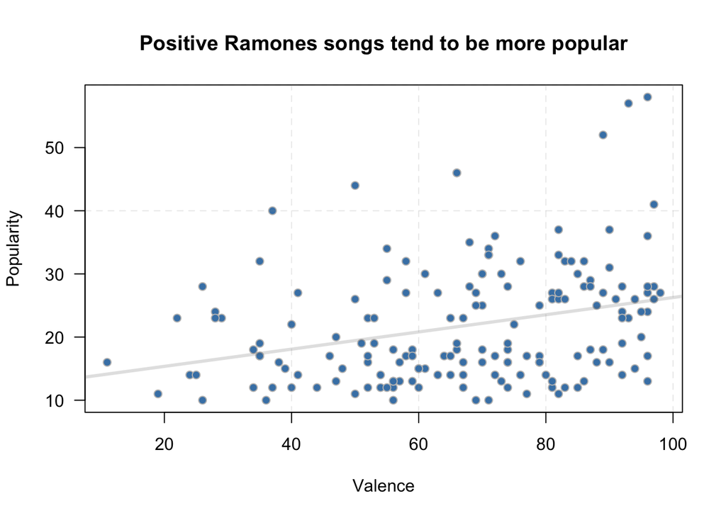

```r
ramoneslm <- lm(pop ~ valence, data=ramones)


plot(pop ~ valence, data=ramones, main="Positive Ramones songs tend to be more popular", xlab="Valence", ylab="Popularity", bg="steelblue", col="gray", pch=21, las=1)
abline(ramoneslm, lwd=3, col=rgb(.4,.4,.4,.2))
abline(v=seq(40,120,20), h=seq(40,120,20), lty=2, col=rgb(.6,.6,.6,.2))
```

```r
pander(summary(ramoneslm))
```

|  | Estimate | Std. Error | t value | Pr(>\|t\|) |
| --- | --- | --- | --- | --- |
| **(Intercept)** | 12.63 | 2.405 | 5.252 | 4.641e-07 |
| **valence** | 0.1363 | 0.0343 | 3.973 | 0.0001063 |

Fitting linear model: pop ~ valence

| Observations | Residual Std. Error | $R^2$ | Adjusted $R^2$ |
| --- | --- | --- | --- |
| 165 | 8.993 | 0.08829 | 0.0827 |

This suggests that there is a positive correlation, though whether it’s significant remains to be seen.

The estimated value of the slope is .1363. This means on average for every one point increase in valence, we can expect to see an increase in popularity of .1363.

One thing to note is that the square of correlation ($R^2$) is very low, which means that there is a lot of variation that is not explained by this model.

That being said, the regression test gives us a p-value less than .05 (.0001063), indicating to reject the null hypothesis, which means there is sufficient evidence to suggest that there is a meaningful relationship.

## Appropriateness of the Regression Analysis

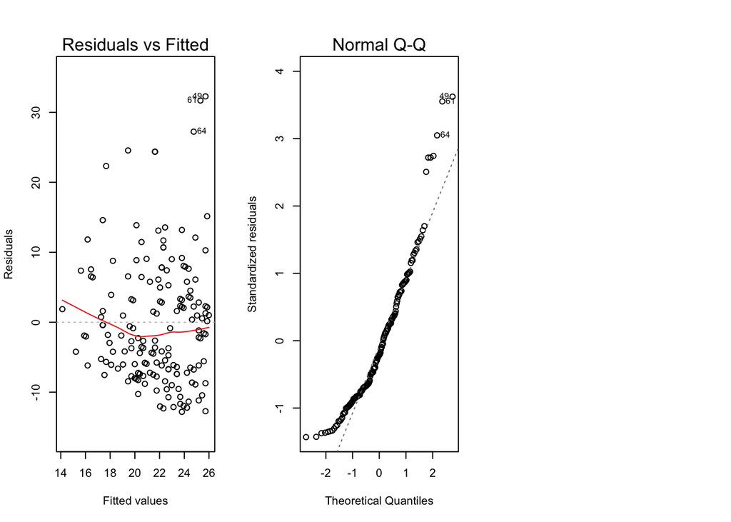

```r
par(mfrow=c(1,3))
plot(ramoneslm, which=1:2)
```